# Risk Factor Analysis

## Outcome Variable

**Outcome Variable:** ever_co

## Predictor Variables

**Intervention Variable:** perdiar6

**Adjustment Set:**

- arm
- sex
- W_mage
- meducyrs
- feducyrs
- hhwealth_quart
- hfoodsec
- W_mhtcm
- W_mwtkg
- W_mbmi
- W_birthwt
- W_birthlen
- W_nrooms
- month
- brthmon
- impfloor
- impsan
- safeh20
- delta_W_mage
- delta_meducyrs
- delta_feducyrs
- delta_hhwealth_quart
- delta_hfoodsec
- delta_W_mhtcm
- delta_W_mwtkg
- delta_W_mbmi
- delta_W_birthwt
- delta_W_birthlen
- delta_W_nrooms
- delta_month
- delta_brthmon
- delta_impfloor
- delta_impsan
- delta_safeh20

## Stratifying Variables

The analysis was stratified on these variable(s):

- agecat
- studyid
- country

## Data Summary

| agecat | studyid | country | perdiar6 | ever_co | n_cell | n |
| --- | --- | --- | --- | --- | --- | --- |
| 0-24 months | ki0047075b-MAL-ED | BANGLADESH | 0% | 0 | 70 | 263 |
| 0-24 months | ki0047075b-MAL-ED | BANGLADESH | 0% | 1 | 15 | 263 |
| 0-24 months | ki0047075b-MAL-ED | BANGLADESH | (0%, 5%] | 0 | 83 | 263 |
| 0-24 months | ki0047075b-MAL-ED | BANGLADESH | (0%, 5%] | 1 | 15 | 263 |
| 0-24 months | ki0047075b-MAL-ED | BANGLADESH | >5% | 0 | 71 | 263 |
| 0-24 months | ki0047075b-MAL-ED | BANGLADESH | >5% | 1 | 9 | 263 |
| 0-24 months | ki0047075b-MAL-ED | BRAZIL | 0% | 0 | 213 | 233 |
| 0-24 months | ki0047075b-MAL-ED | BRAZIL | 0% | 1 | 3 | 233 |
| 0-24 months | ki0047075b-MAL-ED | BRAZIL | (0%, 5%] | 0 | 15 | 233 |
| 0-24 months | ki0047075b-MAL-ED | BRAZIL | (0%, 5%] | 1 | 0 | 233 |
| 0-24 months | ki0047075b-MAL-ED | BRAZIL | >5% | 0 | 2 | 233 |
| 0-24 months | ki0047075b-MAL-ED | BRAZIL | >5% | 1 | 0 | 233 |
| 0-24 months | ki0047075b-MAL-ED | INDIA | 0% | 0 | 46 | 251 |
| 0-24 months | ki0047075b-MAL-ED | INDIA | 0% | 1 | 15 | 251 |
| 0-24 months | ki0047075b-MAL-ED | INDIA | (0%, 5%] | 0 | 105 | 251 |
| 0-24 months | ki0047075b-MAL-ED | INDIA | (0%, 5%] | 1 | 24 | 251 |
| 0-24 months | ki0047075b-MAL-ED | INDIA | >5% | 0 | 46 | 251 |
| 0-24 months | ki0047075b-MAL-ED | INDIA | >5% | 1 | 15 | 251 |
| 0-24 months | ki0047075b-MAL-ED | NEPAL | 0% | 0 | 72 | 240 |
| 0-24 months | ki0047075b-MAL-ED | NEPAL | 0% | 1 | 11 | 240 |
| 0-24 months | ki0047075b-MAL-ED | NEPAL | (0%, 5%] | 0 | 73 | 240 |
| 0-24 months | ki0047075b-MAL-ED | NEPAL | (0%, 5%] | 1 | 4 | 240 |
| 0-24 months | ki0047075b-MAL-ED | NEPAL | >5% | 0 | 73 | 240 |
| 0-24 months | ki0047075b-MAL-ED | NEPAL | >5% | 1 | 7 | 240 |
| 0-24 months | ki0047075b-MAL-ED | PERU | 0% | 0 | 84 | 302 |
| 0-24 months | ki0047075b-MAL-ED | PERU | 0% | 1 | 5 | 302 |
| 0-24 months | ki0047075b-MAL-ED | PERU | (0%, 5%] | 0 | 89 | 302 |
| 0-24 months | ki0047075b-MAL-ED | PERU | (0%, 5%] | 1 | 4 | 302 |
| 0-24 months | ki0047075b-MAL-ED | PERU | >5% | 0 | 117 | 302 |
| 0-24 months | ki0047075b-MAL-ED | PERU | >5% | 1 | 3 | 302 |

[output cut: 204 more lines]

The following strata were considered:

- agecat: 0-24 months, studyid: ki0047075b-MAL-ED, country: BANGLADESH
- agecat: 0-24 months, studyid: ki0047075b-MAL-ED, country: BRAZIL
- agecat: 0-24 months, studyid: ki0047075b-MAL-ED, country: INDIA
- agecat: 0-24 months, studyid: ki0047075b-MAL-ED, country: NEPAL
- agecat: 0-24 months, studyid: ki0047075b-MAL-ED, country: PERU
- agecat: 0-24 months, studyid: ki0047075b-MAL-ED, country: SOUTH AFRICA
- agecat: 0-24 months, studyid: ki0047075b-MAL-ED, country: TANZANIA, UNITED REPUBLIC OF
- agecat: 0-24 months, studyid: ki1000109-EE, country: PAKISTAN
- agecat: 0-24 months, studyid: ki1017093-NIH-Birth, country: BANGLADESH
- agecat: 0-24 months, studyid: ki1017093b-PROVIDE, country: BANGLADESH
- agecat: 0-24 months, studyid: ki1017093c-NIH-Crypto, country: BANGLADESH
- agecat: 0-24 months, studyid: ki1114097-CMIN, country: BANGLADESH
- agecat: 0-24 months, studyid: ki1114097-CONTENT, country: PERU
- agecat: 0-6 months, studyid: ki0047075b-MAL-ED, country: BANGLADESH
- agecat: 0-6 months, studyid: ki0047075b-MAL-ED, country: BRAZIL
- agecat: 0-6 months, studyid: ki0047075b-MAL-ED, country: INDIA
- agecat: 0-6 months, studyid: ki0047075b-MAL-ED, country: NEPAL
- agecat: 0-6 months, studyid: ki0047075b-MAL-ED, country: PERU
- agecat: 0-6 months, studyid: ki0047075b-MAL-ED, country: SOUTH AFRICA
- agecat: 0-6 months, studyid: ki0047075b-MAL-ED, country: TANZANIA, UNITED REPUBLIC OF
- agecat: 0-6 months, studyid: ki1000109-EE, country: PAKISTAN
- agecat: 0-6 months, studyid: ki1017093-NIH-Birth, country: BANGLADESH
- agecat: 0-6 months, studyid: ki1017093b-PROVIDE, country: BANGLADESH
- agecat: 0-6 months, studyid: ki1017093c-NIH-Crypto, country: BANGLADESH
- agecat: 0-6 months, studyid: ki1114097-CMIN, country: BANGLADESH
- agecat: 0-6 months, studyid: ki1114097-CONTENT, country: PERU
- agecat: 6-24 months, studyid: ki0047075b-MAL-ED, country: BANGLADESH
- agecat: 6-24 months, studyid: ki0047075b-MAL-ED, country: BRAZIL
- agecat: 6-24 months, studyid: ki0047075b-MAL-ED, country: INDIA
- agecat: 6-24 months, studyid: ki0047075b-MAL-ED, country: NEPAL
- agecat: 6-24 months, studyid: ki0047075b-MAL-ED, country: PERU
- agecat: 6-24 months, studyid: ki0047075b-MAL-ED, country: SOUTH AFRICA
- agecat: 6-24 months, studyid: ki0047075b-MAL-ED, country: TANZANIA, UNITED REPUBLIC OF
- agecat: 6-24 months, studyid: ki1000109-EE, country: PAKISTAN
- agecat: 6-24 months, studyid: ki1017093-NIH-Birth, country: BANGLADESH
- agecat: 6-24 months, studyid: ki1017093b-PROVIDE, country: BANGLADESH
- agecat: 6-24 months, studyid: ki1017093c-NIH-Crypto, country: BANGLADESH
- agecat: 6-24 months, studyid: ki1114097-CMIN, country: BANGLADESH
- agecat: 6-24 months, studyid: ki1114097-CONTENT, country: PERU

### Dropped Strata

Some strata were dropped due to rare outcomes:

- agecat: 0-24 months, studyid: ki0047075b-MAL-ED, country: BRAZIL
- agecat: 0-24 months, studyid: ki0047075b-MAL-ED, country: NEPAL
- agecat: 0-24 months, studyid: ki0047075b-MAL-ED, country: PERU
- agecat: 0-24 months, studyid: ki0047075b-MAL-ED, country: SOUTH AFRICA
- agecat: 0-24 months, studyid: ki0047075b-MAL-ED, country: TANZANIA, UNITED REPUBLIC OF
- agecat: 0-24 months, studyid: ki1000109-EE, country: PAKISTAN
- agecat: 0-24 months, studyid: ki1114097-CONTENT, country: PERU
- agecat: 0-6 months, studyid: ki0047075b-MAL-ED, country: BANGLADESH
- agecat: 0-6 months, studyid: ki0047075b-MAL-ED, country: BRAZIL
- agecat: 0-6 months, studyid: ki0047075b-MAL-ED, country: NEPAL
- agecat: 0-6 months, studyid: ki0047075b-MAL-ED, country: PERU
- agecat: 0-6 months, studyid: ki0047075b-MAL-ED, country: SOUTH AFRICA
- agecat: 0-6 months, studyid: ki0047075b-MAL-ED, country: TANZANIA, UNITED REPUBLIC OF
- agecat: 0-6 months, studyid: ki1000109-EE, country: PAKISTAN
- agecat: 0-6 months, studyid: ki1017093c-NIH-Crypto, country: BANGLADESH
- agecat: 0-6 months, studyid: ki1114097-CMIN, country: BANGLADESH
- agecat: 0-6 months, studyid: ki1114097-CONTENT, country: PERU
- agecat: 6-24 months, studyid: ki0047075b-MAL-ED, country: BRAZIL
- agecat: 6-24 months, studyid: ki0047075b-MAL-ED, country: NEPAL
- agecat: 6-24 months, studyid: ki0047075b-MAL-ED, country: PERU
- agecat: 6-24 months, studyid: ki0047075b-MAL-ED, country: SOUTH AFRICA
- agecat: 6-24 months, studyid: ki0047075b-MAL-ED, country: TANZANIA, UNITED REPUBLIC OF
- agecat: 6-24 months, studyid: ki1000109-EE, country: PAKISTAN
- agecat: 6-24 months, studyid: ki1114097-CONTENT, country: PERU

## Methods Detail

We’re interested in the causal parameters $E[Y_a]$ for all values of $a \in \mathcal{A}$. These parameters represent the mean outcome if, possibly contrary to fact, we intervened to set all units to have $A=a$. Under the randomization and positivity assumptions, these are identified by the statistical parameters $\psi_a=E_W[E_{Y|A,W}(Y|A=a,W)]$. In addition, we’re interested in the mean of $Y$, $E[Y]$ under no intervention (the observed mean). We will estimate these parameters by using SuperLearner to fit the relevant likelihood factors – $E_{Y|A,W}(Y|A=a,W)$ and $p(A=a|W)$, and then updating our likelihood fit using a joint TMLE.

For unadjusted analyses ($W=\{\}$), initial likelihoods were estimated using Lrnr_glm to estimate the simple $E(Y|A)$ and Lrnr_mean to estimate $p(A)$. For adjusted analyses, a small library containing Lrnr_glmnet, Lrnr_xgboost, and Lrnr_mean was used.

Having estimated these parameters, we will then use the delta method to estimate relative risks and attributable risks relative to a prespecified baseline level of $A$.

# Results Detail

## Results Plots

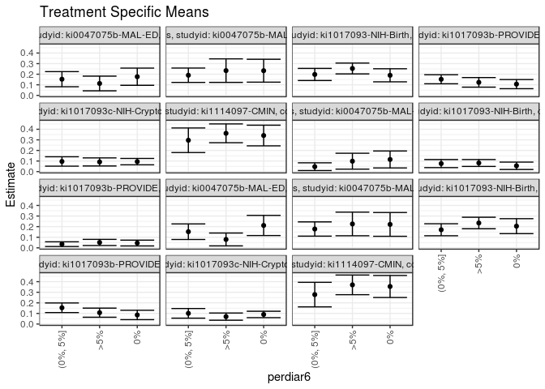

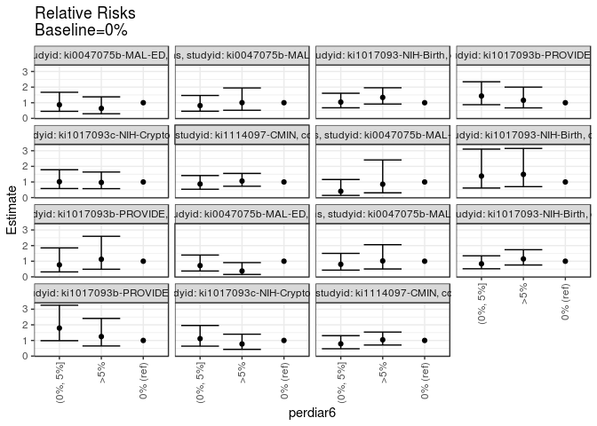

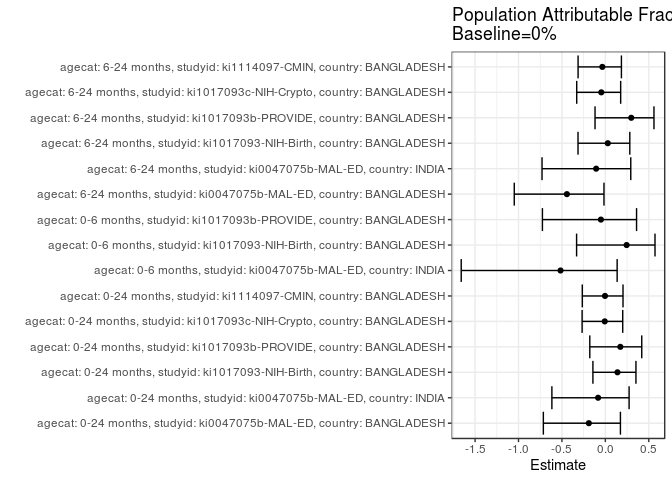

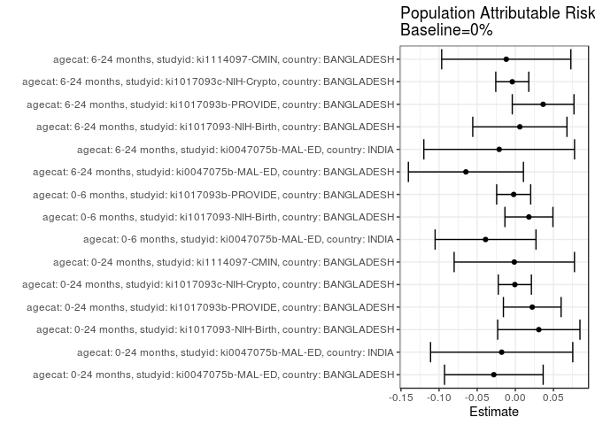

## Results Table

### Parameter: TSM

| agecat | studyid | country | intervention_level | baseline_level | estimate | ci_lower | ci_upper |
| --- | --- | --- | --- | --- | --- | --- | --- |
| 0-24 months | ki0047075b-MAL-ED | BANGLADESH | 0% | NA | 0.1764706 | 0.0952733 | 0.2576679 |
| 0-24 months | ki0047075b-MAL-ED | BANGLADESH | (0%, 5%] | NA | 0.1530612 | 0.0816411 | 0.2244814 |
| 0-24 months | ki0047075b-MAL-ED | BANGLADESH | >5% | NA | 0.1125000 | 0.0431270 | 0.1818730 |
| 0-24 months | ki0047075b-MAL-ED | INDIA | 0% | NA | 0.2330620 | 0.1249299 | 0.3411940 |
| 0-24 months | ki0047075b-MAL-ED | INDIA | (0%, 5%] | NA | 0.1903431 | 0.1224822 | 0.2582040 |
| 0-24 months | ki0047075b-MAL-ED | INDIA | >5% | NA | 0.2338301 | 0.1227950 | 0.3448653 |
| 0-24 months | ki1017093-NIH-Birth | BANGLADESH | 0% | NA | 0.1898143 | 0.1280383 | 0.2515904 |
| 0-24 months | ki1017093-NIH-Birth | BANGLADESH | (0%, 5%] | NA | 0.1977473 | 0.1406396 | 0.2548549 |
| 0-24 months | ki1017093-NIH-Birth | BANGLADESH | >5% | NA | 0.2541083 | 0.2028907 | 0.3053260 |
| 0-24 months | ki1017093b-PROVIDE | BANGLADESH | 0% | NA | 0.1063855 | 0.0631723 | 0.1495987 |
| 0-24 months | ki1017093b-PROVIDE | BANGLADESH | (0%, 5%] | NA | 0.1522521 | 0.1096644 | 0.1948398 |
| 0-24 months | ki1017093b-PROVIDE | BANGLADESH | >5% | NA | 0.1230852 | 0.0778904 | 0.1682801 |
| 0-24 months | ki1017093c-NIH-Crypto | BANGLADESH | 0% | NA | 0.0943169 | 0.0642371 | 0.1243968 |
| 0-24 months | ki1017093c-NIH-Crypto | BANGLADESH | (0%, 5%] | NA | 0.0958716 | 0.0515584 | 0.1401847 |
| 0-24 months | ki1017093c-NIH-Crypto | BANGLADESH | >5% | NA | 0.0912756 | 0.0532255 | 0.1293257 |
| 0-24 months | ki1114097-CMIN | BANGLADESH | 0% | NA | 0.3408370 | 0.2433788 | 0.4382952 |
| 0-24 months | ki1114097-CMIN | BANGLADESH | (0%, 5%] | NA | 0.2960956 | 0.1799825 | 0.4122087 |
| 0-24 months | ki1114097-CMIN | BANGLADESH | >5% | NA | 0.3616510 | 0.2728343 | 0.4504678 |
| 0-6 months | ki0047075b-MAL-ED | INDIA | 0% | NA | 0.1147541 | 0.0346110 | 0.1948972 |
| 0-6 months | ki0047075b-MAL-ED | INDIA | (0%, 5%] | NA | 0.0465116 | 0.0100985 | 0.0829248 |
| 0-6 months | ki0047075b-MAL-ED | INDIA | >5% | NA | 0.0983607 | 0.0234787 | 0.1732426 |
| 0-6 months | ki1017093-NIH-Birth | BANGLADESH | 0% | NA | 0.0548780 | 0.0199945 | 0.0897616 |
| 0-6 months | ki1017093-NIH-Birth | BANGLADESH | (0%, 5%] | NA | 0.0756757 | 0.0375337 | 0.1138177 |
| 0-6 months | ki1017093-NIH-Birth | BANGLADESH | >5% | NA | 0.0814815 | 0.0488234 | 0.1141396 |
| 0-6 months | ki1017093b-PROVIDE | BANGLADESH | 0% | NA | 0.0450450 | 0.0177429 | 0.0723472 |
| 0-6 months | ki1017093b-PROVIDE | BANGLADESH | (0%, 5%] | NA | 0.0344828 | 0.0123304 | 0.0566351 |
| 0-6 months | ki1017093b-PROVIDE | BANGLADESH | >5% | NA | 0.0506912 | 0.0214834 | 0.0798990 |
| 6-24 months | ki0047075b-MAL-ED | BANGLADESH | 0% | NA | 0.2112676 | 0.1161172 | 0.3064180 |
| 6-24 months | ki0047075b-MAL-ED | BANGLADESH | (0%, 5%] | NA | 0.1521739 | 0.0786230 | 0.2257248 |
| 6-24 months | ki0047075b-MAL-ED | BANGLADESH | >5% | NA | 0.0789474 | 0.0181951 | 0.1396997 |
| 6-24 months | ki0047075b-MAL-ED | INDIA | 0% | NA | 0.2211610 | 0.1089425 | 0.3333796 |
| 6-24 months | ki0047075b-MAL-ED | INDIA | (0%, 5%] | NA | 0.1774819 | 0.1102223 | 0.2447415 |
| 6-24 months | ki0047075b-MAL-ED | INDIA | >5% | NA | 0.2252788 | 0.1137950 | 0.3367626 |
| 6-24 months | ki1017093-NIH-Birth | BANGLADESH | 0% | NA | 0.2044065 | 0.1337220 | 0.2750910 |
| 6-24 months | ki1017093-NIH-Birth | BANGLADESH | (0%, 5%] | NA | 0.1705561 | 0.1138988 | 0.2272133 |
| 6-24 months | ki1017093-NIH-Birth | BANGLADESH | >5% | NA | 0.2343874 | 0.1800599 | 0.2887149 |
| 6-24 months | ki1017093b-PROVIDE | BANGLADESH | 0% | NA | 0.0857017 | 0.0412158 | 0.1301875 |
| 6-24 months | ki1017093b-PROVIDE | BANGLADESH | (0%, 5%] | NA | 0.1534936 | 0.1081925 | 0.1987947 |
| 6-24 months | ki1017093b-PROVIDE | BANGLADESH | >5% | NA | 0.1070850 | 0.0639133 | 0.1502566 |
| 6-24 months | ki1017093c-NIH-Crypto | BANGLADESH | 0% | NA | 0.0903127 | 0.0600418 | 0.1205836 |
| 6-24 months | ki1017093c-NIH-Crypto | BANGLADESH | (0%, 5%] | NA | 0.1008141 | 0.0553055 | 0.1463227 |
| 6-24 months | ki1017093c-NIH-Crypto | BANGLADESH | >5% | NA | 0.0699870 | 0.0358779 | 0.1040960 |
| 6-24 months | ki1114097-CMIN | BANGLADESH | 0% | NA | 0.3545236 | 0.2502970 | 0.4587502 |
| 6-24 months | ki1114097-CMIN | BANGLADESH | (0%, 5%] | NA | 0.2778636 | 0.1619257 | 0.3938014 |
| 6-24 months | ki1114097-CMIN | BANGLADESH | >5% | NA | 0.3698682 | 0.2771246 | 0.4626117 |

### Parameter: E(Y)

| agecat | studyid | country | intervention_level | baseline_level | estimate | ci_lower | ci_upper |
| --- | --- | --- | --- | --- | --- | --- | --- |
| 0-24 months | ki0047075b-MAL-ED | BANGLADESH | NA | NA | 0.1482890 | 0.1052563 | 0.1913216 |
| 0-24 months | ki0047075b-MAL-ED | INDIA | NA | NA | 0.2151394 | 0.1642023 | 0.2660766 |
| 0-24 months | ki1017093-NIH-Birth | BANGLADESH | NA | NA | 0.2206119 | 0.1879724 | 0.2532514 |
| 0-24 months | ki1017093b-PROVIDE | BANGLADESH | NA | NA | 0.1285714 | 0.1037574 | 0.1533855 |
| 0-24 months | ki1017093c-NIH-Crypto | BANGLADESH | NA | NA | 0.0936675 | 0.0729118 | 0.1144233 |
| 0-24 months | ki1114097-CMIN | BANGLADESH | NA | NA | 0.3394834 | 0.2830004 | 0.3959663 |
| 0-6 months | ki0047075b-MAL-ED | INDIA | NA | NA | 0.0756972 | 0.0429084 | 0.1084860 |
| 0-6 months | ki1017093-NIH-Birth | BANGLADESH | NA | NA | 0.0726979 | 0.0522275 | 0.0931683 |
| 0-6 months | ki1017093b-PROVIDE | BANGLADESH | NA | NA | 0.0428571 | 0.0278427 | 0.0578716 |
| 6-24 months | ki0047075b-MAL-ED | BANGLADESH | NA | NA | 0.1464435 | 0.1015265 | 0.1913605 |
| 6-24 months | ki0047075b-MAL-ED | INDIA | NA | NA | 0.2000000 | 0.1487493 | 0.2512507 |
| 6-24 months | ki1017093-NIH-Birth | BANGLADESH | NA | NA | 0.2103321 | 0.1759902 | 0.2446740 |
| 6-24 months | ki1017093b-PROVIDE | BANGLADESH | NA | NA | 0.1221498 | 0.0962275 | 0.1480722 |
| 6-24 months | ki1017093c-NIH-Crypto | BANGLADESH | NA | NA | 0.0863014 | 0.0659171 | 0.1066856 |
| 6-24 months | ki1114097-CMIN | BANGLADESH | NA | NA | 0.3426295 | 0.2837999 | 0.4014590 |

### Parameter: RR

| agecat | studyid | country | intervention_level | baseline_level | estimate | ci_lower | ci_upper |
| --- | --- | --- | --- | --- | --- | --- | --- |
| 0-24 months | ki0047075b-MAL-ED | BANGLADESH | 0% | 0% | 1.0000000 | 1.0000000 | 1.0000000 |
| 0-24 months | ki0047075b-MAL-ED | BANGLADESH | (0%, 5%] | 0% | 0.8673469 | 0.4503955 | 1.6702892 |
| 0-24 months | ki0047075b-MAL-ED | BANGLADESH | >5% | 0% | 0.6375000 | 0.2953502 | 1.3760149 |
| 0-24 months | ki0047075b-MAL-ED | INDIA | 0% | 0% | 1.0000000 | 1.0000000 | 1.0000000 |
| 0-24 months | ki0047075b-MAL-ED | INDIA | (0%, 5%] | 0% | 0.8167061 | 0.4556514 | 1.4638578 |
| 0-24 months | ki0047075b-MAL-ED | INDIA | >5% | 0% | 1.0032960 | 0.5176222 | 1.9446670 |
| 0-24 months | ki1017093-NIH-Birth | BANGLADESH | 0% | 0% | 1.0000000 | 1.0000000 | 1.0000000 |
| 0-24 months | ki1017093-NIH-Birth | BANGLADESH | (0%, 5%] | 0% | 1.0417931 | 0.6754860 | 1.6067435 |
| 0-24 months | ki1017093-NIH-Birth | BANGLADESH | >5% | 0% | 1.3387204 | 0.9156404 | 1.9572884 |
| 0-24 months | ki1017093b-PROVIDE | BANGLADESH | 0% | 0% | 1.0000000 | 1.0000000 | 1.0000000 |
| 0-24 months | ki1017093b-PROVIDE | BANGLADESH | (0%, 5%] | 0% | 1.4311355 | 0.8745881 | 2.3418439 |
| 0-24 months | ki1017093b-PROVIDE | BANGLADESH | >5% | 0% | 1.1569737 | 0.6693431 | 1.9998536 |
| 0-24 months | ki1017093c-NIH-Crypto | BANGLADESH | 0% | 0% | 1.0000000 | 1.0000000 | 1.0000000 |
| 0-24 months | ki1017093c-NIH-Crypto | BANGLADESH | (0%, 5%] | 0% | 1.0164830 | 0.5797410 | 1.7822403 |
| 0-24 months | ki1017093c-NIH-Crypto | BANGLADESH | >5% | 0% | 0.9677541 | 0.5726806 | 1.6353758 |
| 0-24 months | ki1114097-CMIN | BANGLADESH | 0% | 0% | 1.0000000 | 1.0000000 | 1.0000000 |
| 0-24 months | ki1114097-CMIN | BANGLADESH | (0%, 5%] | 0% | 0.8687308 | 0.5348464 | 1.4110469 |
| 0-24 months | ki1114097-CMIN | BANGLADESH | >5% | 0% | 1.0610675 | 0.7273182 | 1.5479666 |
| 0-6 months | ki0047075b-MAL-ED | INDIA | 0% | 0% | 1.0000000 | 1.0000000 | 1.0000000 |
| 0-6 months | ki0047075b-MAL-ED | INDIA | (0%, 5%] | 0% | 0.4053156 | 0.1419600 | 1.1572328 |
| 0-6 months | ki0047075b-MAL-ED | INDIA | >5% | 0% | 0.8571429 | 0.3050544 | 2.4084031 |
| 0-6 months | ki1017093-NIH-Birth | BANGLADESH | 0% | 0% | 1.0000000 | 1.0000000 | 1.0000000 |
| 0-6 months | ki1017093-NIH-Birth | BANGLADESH | (0%, 5%] | 0% | 1.3789790 | 0.6126960 | 3.1036321 |
| 0-6 months | ki1017093-NIH-Birth | BANGLADESH | >5% | 0% | 1.4847737 | 0.7003297 | 3.1478783 |
| 0-6 months | ki1017093b-PROVIDE | BANGLADESH | 0% | 0% | 1.0000000 | 1.0000000 | 1.0000000 |
| 0-6 months | ki1017093b-PROVIDE | BANGLADESH | (0%, 5%] | 0% | 0.7655172 | 0.3165046 | 1.8515265 |
| 0-6 months | ki1017093b-PROVIDE | BANGLADESH | >5% | 0% | 1.1253456 | 0.4876348 | 2.5970311 |
| 6-24 months | ki0047075b-MAL-ED | BANGLADESH | 0% | 0% | 1.0000000 | 1.0000000 | 1.0000000 |
| 6-24 months | ki0047075b-MAL-ED | BANGLADESH | (0%, 5%] | 0% | 0.7202899 | 0.3720423 | 1.3945120 |
| 6-24 months | ki0047075b-MAL-ED | BANGLADESH | >5% | 0% | 0.3736842 | 0.1532046 | 0.9114602 |
| 6-24 months | ki0047075b-MAL-ED | INDIA | 0% | 0% | 1.0000000 | 1.0000000 | 1.0000000 |
| 6-24 months | ki0047075b-MAL-ED | INDIA | (0%, 5%] | 0% | 0.8025009 | 0.4292667 | 1.5002507 |
| 6-24 months | ki0047075b-MAL-ED | INDIA | >5% | 0% | 1.0186189 | 0.5038879 | 2.0591570 |
| 6-24 months | ki1017093-NIH-Birth | BANGLADESH | 0% | 0% | 1.0000000 | 1.0000000 | 1.0000000 |
| 6-24 months | ki1017093-NIH-Birth | BANGLADESH | (0%, 5%] | 0% | 0.8343966 | 0.5170345 | 1.3465592 |
| 6-24 months | ki1017093-NIH-Birth | BANGLADESH | >5% | 0% | 1.1466731 | 0.7569321 | 1.7370901 |
| 6-24 months | ki1017093b-PROVIDE | BANGLADESH | 0% | 0% | 1.0000000 | 1.0000000 | 1.0000000 |
| 6-24 months | ki1017093b-PROVIDE | BANGLADESH | (0%, 5%] | 0% | 1.7910224 | 0.9855232 | 3.2548816 |
| 6-24 months | ki1017093b-PROVIDE | BANGLADESH | >5% | 0% | 1.2495086 | 0.6480807 | 2.4090701 |
| 6-24 months | ki1017093c-NIH-Crypto | BANGLADESH | 0% | 0% | 1.0000000 | 1.0000000 | 1.0000000 |
| 6-24 months | ki1017093c-NIH-Crypto | BANGLADESH | (0%, 5%] | 0% | 1.1162784 | 0.6361573 | 1.9587569 |
| 6-24 months | ki1017093c-NIH-Crypto | BANGLADESH | >5% | 0% | 0.7749408 | 0.4288341 | 1.4003859 |
| 6-24 months | ki1114097-CMIN | BANGLADESH | 0% | 0% | 1.0000000 | 1.0000000 | 1.0000000 |
| 6-24 months | ki1114097-CMIN | BANGLADESH | (0%, 5%] | 0% | 0.7837660 | 0.4699189 | 1.3072238 |
| 6-24 months | ki1114097-CMIN | BANGLADESH | >5% | 0% | 1.0432822 | 0.7080240 | 1.5372893 |

### Parameter: PAR

| agecat | studyid | country | intervention_level | baseline_level | estimate | ci_lower | ci_upper |
| --- | --- | --- | --- | --- | --- | --- | --- |
| 0-24 months | ki0047075b-MAL-ED | BANGLADESH | 0% | NA | -0.0281816 | -0.0928591 | 0.0364958 |
| 0-24 months | ki0047075b-MAL-ED | INDIA | 0% | NA | -0.0179225 | -0.1111602 | 0.0753152 |
| 0-24 months | ki1017093-NIH-Birth | BANGLADESH | 0% | NA | 0.0307976 | -0.0231397 | 0.0847349 |
| 0-24 months | ki1017093b-PROVIDE | BANGLADESH | 0% | NA | 0.0221859 | -0.0156498 | 0.0600217 |
| 0-24 months | ki1017093c-NIH-Crypto | BANGLADESH | 0% | NA | -0.0006494 | -0.0223581 | 0.0210593 |
| 0-24 months | ki1114097-CMIN | BANGLADESH | 0% | NA | -0.0013536 | -0.0802507 | 0.0775436 |
| 0-6 months | ki0047075b-MAL-ED | INDIA | 0% | NA | -0.0390569 | -0.1052092 | 0.0270954 |
| 0-6 months | ki1017093-NIH-Birth | BANGLADESH | 0% | NA | 0.0178199 | -0.0136619 | 0.0493016 |
| 0-6 months | ki1017093b-PROVIDE | BANGLADESH | 0% | NA | -0.0021879 | -0.0245047 | 0.0201289 |
| 6-24 months | ki0047075b-MAL-ED | BANGLADESH | 0% | NA | -0.0648241 | -0.1402695 | 0.0106213 |
| 6-24 months | ki0047075b-MAL-ED | INDIA | 0% | NA | -0.0211610 | -0.1199809 | 0.0776588 |
| 6-24 months | ki1017093-NIH-Birth | BANGLADESH | 0% | NA | 0.0059256 | -0.0558401 | 0.0676913 |
| 6-24 months | ki1017093b-PROVIDE | BANGLADESH | 0% | NA | 0.0364482 | -0.0040177 | 0.0769141 |
| 6-24 months | ki1017093c-NIH-Crypto | BANGLADESH | 0% | NA | -0.0040113 | -0.0256587 | 0.0176361 |
| 6-24 months | ki1114097-CMIN | BANGLADESH | 0% | NA | -0.0118941 | -0.0966029 | 0.0728147 |

### Parameter: PAF

| agecat | studyid | country | intervention_level | baseline_level | estimate | ci_lower | ci_upper |
| --- | --- | --- | --- | --- | --- | --- | --- |
| 0-24 months | ki0047075b-MAL-ED | BANGLADESH | 0% | NA | -0.1900452 | -0.7139097 | 0.1736976 |
| 0-24 months | ki0047075b-MAL-ED | INDIA | 0% | NA | -0.0833065 | -0.6156087 | 0.2736156 |
| 0-24 months | ki1017093-NIH-Birth | BANGLADESH | 0% | NA | 0.1396007 | -0.1430889 | 0.3523803 |
| 0-24 months | ki1017093b-PROVIDE | BANGLADESH | 0% | NA | 0.1725571 | -0.1789807 | 0.4192765 |
| 0-24 months | ki1017093c-NIH-Crypto | BANGLADESH | 0% | NA | -0.0069328 | -0.2675390 | 0.2000926 |
| 0-24 months | ki1114097-CMIN | BANGLADESH | 0% | NA | -0.0039872 | -0.2654841 | 0.2034746 |
| 0-6 months | ki0047075b-MAL-ED | INDIA | 0% | NA | -0.5159620 | -1.6595874 | 0.1359032 |
| 0-6 months | ki1017093-NIH-Birth | BANGLADESH | 0% | NA | 0.2451220 | -0.3311018 | 0.5719029 |
| 0-6 months | ki1017093b-PROVIDE | BANGLADESH | 0% | NA | -0.0510511 | -0.7245378 | 0.3594178 |
| 6-24 months | ki0047075b-MAL-ED | BANGLADESH | 0% | NA | -0.4426559 | -1.0488447 | -0.0158194 |
| 6-24 months | ki0047075b-MAL-ED | INDIA | 0% | NA | -0.1058051 | -0.7290687 | 0.2927956 |
| 6-24 months | ki1017093-NIH-Birth | BANGLADESH | 0% | NA | 0.0281726 | -0.3147323 | 0.2816420 |
| 6-24 months | ki1017093b-PROVIDE | BANGLADESH | 0% | NA | 0.2983890 | -0.1187043 | 0.5599749 |
| 6-24 months | ki1017093c-NIH-Crypto | BANGLADESH | 0% | NA | -0.0464800 | -0.3297263 | 0.1764317 |
| 6-24 months | ki1114097-CMIN | BANGLADESH | 0% | NA | -0.0347142 | -0.3139011 | 0.1851491 |